# Heart Disease Challenge

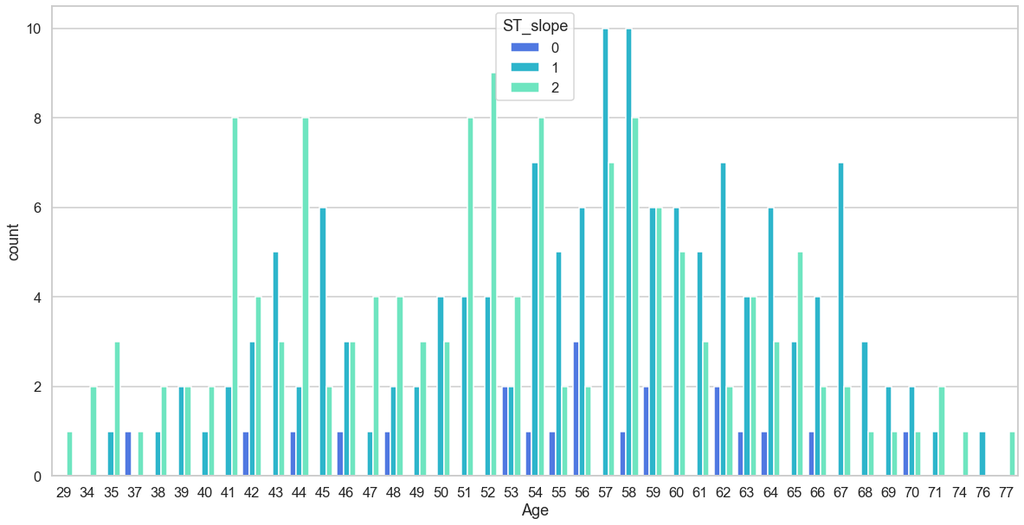

```python
plt.figure(figsize=(20, 10)) # change the size of the plot
sns.countplot(x = 'Age',hue = 'ST_slope', data = df)
```

The dependence of result of ST Slope on age.

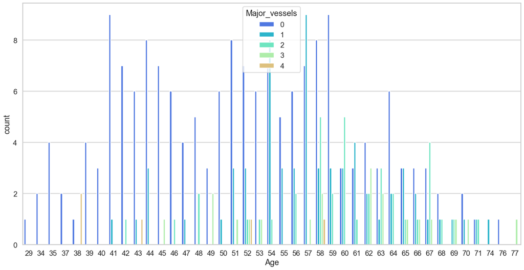

```python
plt.figure(figsize=(20, 10)) # change the size of the plot
sns.countplot(x = 'Age',hue = 'Major_vessels', data = df)
```

The dependence of result of Major vessels being blocked with age.

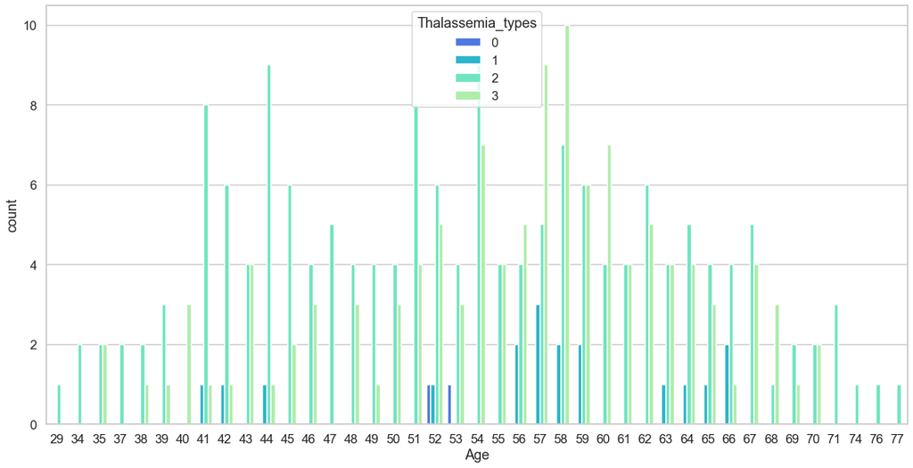

```python
plt.figure(figsize=(20, 10)) # change the size of the plot
sns.countplot(x = 'Age',hue = 'Thalassemia_types', data = df)
```

The dependence of result of Thalassemia on age.

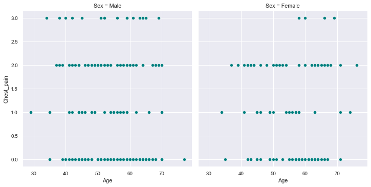

```python
sns.set(font_scale=0.9) # change the font size for the next plots

sns.relplot(x ='Age', y ='Chest_pain', col = 'Sex', data = df, color="teal", height = 5)
```

Relationship between Chest Pain, Age and Sex.

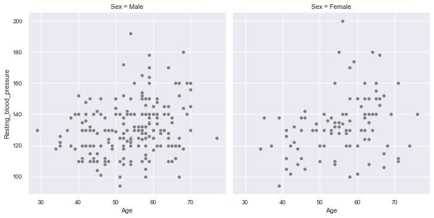

```python
sns.relplot(x ='Age', y ='Resting_blood_pressure', col = 'Sex', data = df, color = 'grey')
```

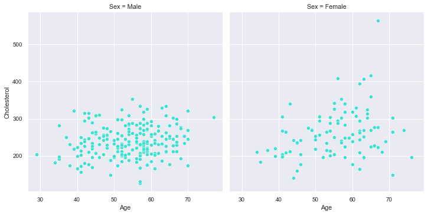

```python
sns.relplot(x ='Age', y ='Cholesterol', col = 'Sex', data = df, color = 'turquoise')
```

Relationship between Cholesterol, Age and Sex.

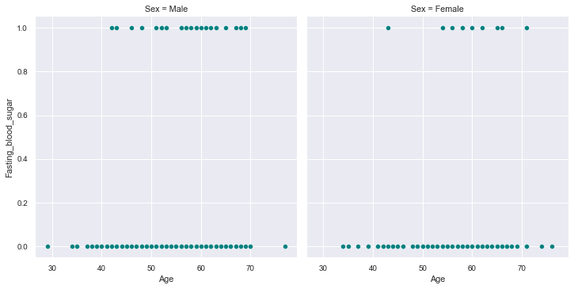

```python
sns.relplot(x ='Age', y ='Fasting_blood_sugar', col = 'Sex', data = df, color = 'teal')
```

Relationship between Fasting Blood Sugar, Age and Sex.

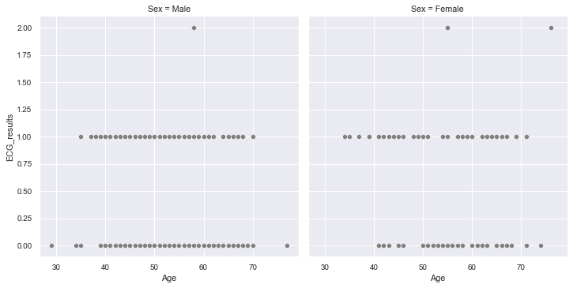

```python
sns.relplot(x ='Age', y ='ECG_results', col = 'Sex', data = df, color = 'grey')
```

Relationship between ECG Results, Age and Sex.

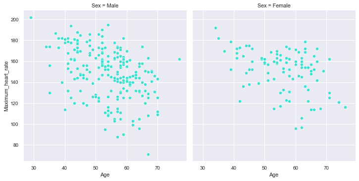

```python
sns.relplot(x ='Age', y ='Maximum_heart_rate', col = 'Sex', data = df, color = 'turquoise')
```

Relationship between Maximum Heart Rate, Age and Sex.

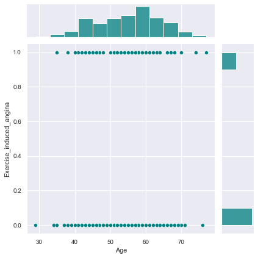

```python
sns.jointplot(x =df['Age'], y =df['Exercise_induced_angina'], data = df, color = 'teal')
```

Relationship between Exercise Induced Angina and Age. The Age peaks at about 60 and Exercise Induced Angina problem is more at value 0.

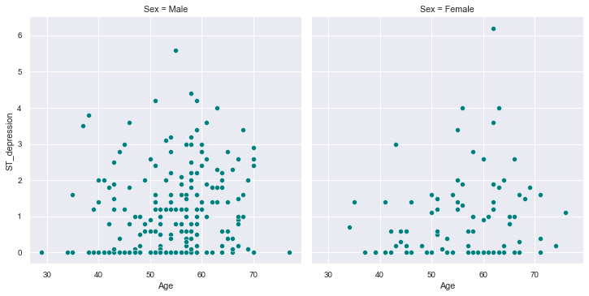

```python
sns.relplot(x ='Age', y ='ST_depression', col = 'Sex', data = df, color = 'teal')
```

Relationship between ST_depression, Age and Sex.

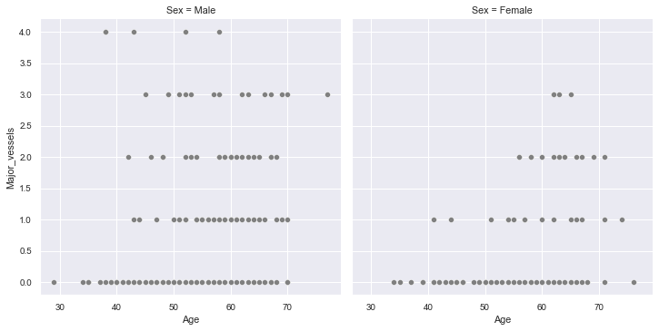

```python
sns.relplot(x ='Age', y ='Major_vessels', col = 'Sex', data = df, color = 'grey')
```

Relationship between Major_vessels, Age and Sex.

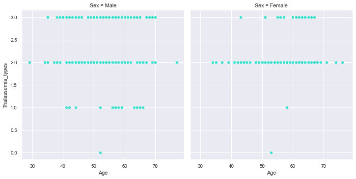

```python
sns.relplot(x ='Age', y ='Thalassemia_types', col = 'Sex', data = df, color = 'turquoise')
```

Relationship between Thalassemia type, Age and Sex.

### 6. Exploratory Data Analysis (EDA)

```python
# Libraries for model selection
from sklearn.ensemble import RandomForestClassifier #for the model
from sklearn.tree import DecisionTreeClassifier
from sklearn.tree import export_graphviz #plot tree
from sklearn.metrics import roc_curve, auc #for model evaluation
from sklearn.metrics import classification_report #for model evaluation
from sklearn.metrics import confusion_matrix #for model evaluation
from sklearn.model_selection import train_test_split #for data splitting

import eli5 #for purmutation importance
from eli5.sklearn import PermutationImportance
import shap #for SHAP (SHapley Additive exPlanations) values
from pdpbox import pdp, info_plots #for partial plots
np.random.seed(123) #ensure reproducibility

pd.options.mode.chained_assignment = None  #hide any pandas warnings
```

### Classification Model. Random Forests

```python
X_train, X_test, y_train, y_test = train_test_split(data.drop('Heart_attack', 1), data['Heart_attack'], test_size= .2, random_state=10) # split the data
```

```python
# Model
model = RandomForestClassifier(max_depth=5)
model.fit(X_train, y_train)
```

```
RandomForestClassifier(max_depth=5)
```

We can plot the consequent decision tree, to see what it's doing

```python
estimator = model.estimators_[1]
feature_names = [i for i in X_train.columns]

y_train_str = y_train.astype('str')
y_train_str[y_train_str == '0'] = 'no disease'
y_train_str[y_train_str == '1'] = 'disease'
y_train_str = y_train_str.values
```

**Visualize a Decision Tree from a Random Forest in Python**

```python
# code from https://towardsdatascience.com/how-to-visualize-a-decision-tree-from-a-random-forest-in-python-using-scikit-learn-38ad2d75f21c

# Export as dot file
export_graphviz(estimator, out_file='tree.dot',
                feature_names = feature_names,
                class_names = y_train_str,
                rounded = True, proportion = True,
                label='root',
                precision = 2, filled = True)

# Convert to png using system command (requires Graphviz)
from subprocess import call
call(['dot', '-Tpng', 'tree.dot', '-o', 'tree.png', '-Gdpi=600'], shell=True)

# Display in jupyter notebook
# from IPython.display import Image
# Image(filename = 'tree.png')
```

```
1
```

Let's evaluate the model

```python
y_predict = model.predict(X_test)
y_pred_quant = model.predict_proba(X_test)[:, 1]
y_pred_bin = model.predict(X_test)
```

Assess the fit with a confusion matrix

```python
confusion_matrix = confusion_matrix(y_test, y_pred_bin)
confusion_matrix
```

```
array([[28,  7],
       [ 5, 21]], dtype=int64)
```

```
  True Negative = 28
  False Positive = 7
  False Negative = 5
  True Positive = 21
```

Diagnostic tests are often defined with sensitivity and specificity as the headline metrics. **Sensitivity** is the metric that evaluates a model’s ability to predict true positives of each available category. **Specificity** is the metric that evaluates a model’s ability to predict true negatives of each available category. These metrics apply to any categorical model. The equations for calculating these metrics are below.

\begin{align} Sensitivity = \frac{True\:Positives}{True\:Positives + False\:Negatives} \end{align}

\begin{align} Specificity = \frac{True\:Negatives}{True\:Negatives + False\:Positives} \end{align}

```python
total=sum(sum(confusion_matrix))

sensitivity = confusion_matrix[0,0]/(confusion_matrix[0,0]+confusion_matrix[1,0])
print('Sensitivity : ', sensitivity )

specificity = confusion_matrix[1,1]/(confusion_matrix[1,1]+confusion_matrix[0,1])
print('Specificity : ', specificity)
```

```
Sensitivity :  0.8484848484848485
Specificity :  0.75
```

Let's also check with a [Receiver Operator Curve (ROC)](https://en.wikipedia.org/wiki/Receiver_operating_characteristic),

[figure not shown]

```python
fpr, tpr, thresholds = roc_curve(y_test, y_pred_quant)

fig, ax = plt.subplots()
ax.plot(fpr, tpr)
ax.plot([0, 1], [0, 1], transform=ax.transAxes, ls="--", c=".3")
plt.xlim([0.0, 1.0])
plt.ylim([0.0, 1.0])
plt.rcParams['font.size'] = 12
plt.title('ROC curve for diabetes classifier')
plt.xlabel('False Positive Rate (1 - Specificity)')
plt.ylabel('True Positive Rate (Sensitivity)')
plt.grid(True)
```

Another common metric is the **Area Under the Curve(AUC)**. This is a convenient way to capture the performance of a model in a single number, although it's not without certain issues. As a rule of thumb, an AUC can be classed as follows:

```
0.90 - 1.00 = excellent
0.80 - 0.90 = good
0.70 - 0.80 = fair
0.60 - 0.70 = poor
0.50 - 0.60 = fail
```

```python
auc(fpr, tpr)
```

```
0.9142857142857144
```

Expected Output

- 0.9142857142857144

### 7. Explanation. Model Validation

ML explainability tools

**Permutation importance** is the first tool for understanding a machine-learning model, and involves shuffling individual variables in the validation data (after a model has been fit), and seeing the effect on accuracy. Learn more [here](https://www.kaggle.com/dansbecker/permutation-importance).

```python
perm = PermutationImportance(model, random_state=1).fit(X_test, y_test)
eli5.show_weights(perm, feature_names = X_test.columns.tolist())
```

| Weight | Feature |
| --- | --- |
| 0.0525 ± 0.0321 | Chest_pain |
| 0.0197 ± 0.0245 | ST_depression |
| 0.0131 ± 0.0525 | Thalassemia_types |
| 0.0131 ± 0.0669 | Major_vessels |
| 0.0131 ± 0.0564 | Age |
| 0.0066 ± 0.0262 | Sex |
| 0.0000 ± 0.0207 | ST_slope |
| 0 ± 0.0000 | Fasting_blood_sugar |
| -0.0033 ± 0.0131 | ECG_results |
| -0.0033 ± 0.0245 | Cholesterol |
| -0.0066 ± 0.0161 | Exercise_induced_angina |
| -0.0197 ± 0.0131 | Resting_blood_pressure |
| -0.0295 ± 0.0525 | Maximum_heart_rate |

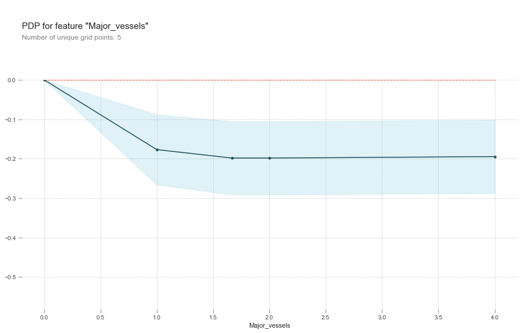

```python
base_features = data.columns.values.tolist()
base_features.remove('Heart_attack')

feat_name = 'Major_vessels'
pdp_dist = pdp.pdp_isolate(model=model, dataset=X_test, model_features=base_features, feature=feat_name)

pdp.pdp_plot(pdp_dist, feat_name)
plt.show()
```

As we can see that as the number of major blood vessels increases, the probability of heart disease decreases which makes sense, as it means more blood can get to the heart.

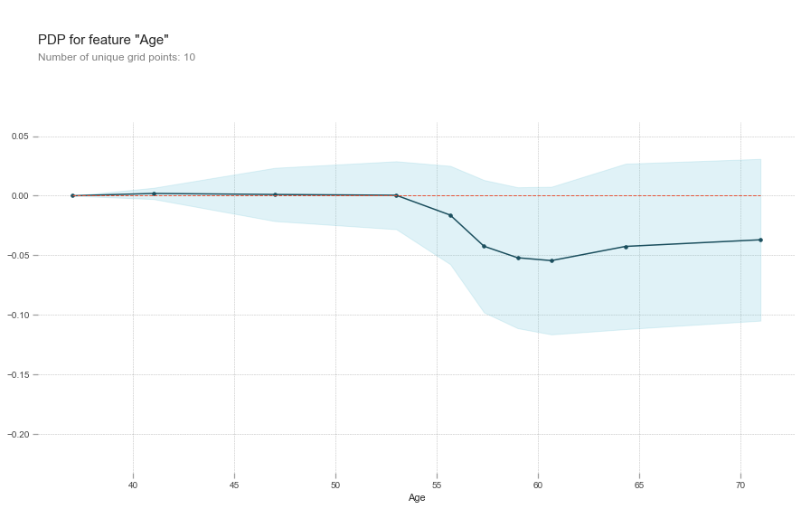

```python
feat_name = 'Age'
pdp_dist = pdp.pdp_isolate(model=model, dataset=X_test, model_features=base_features, feature=feat_name)

pdp.pdp_plot(pdp_dist, feat_name)
plt.show()
```

That's a bit strange. The higher the age, the lower the chance of heart disease? Althought the blue confidence regions show that this might not be true (the red baseline is within the blue zone)

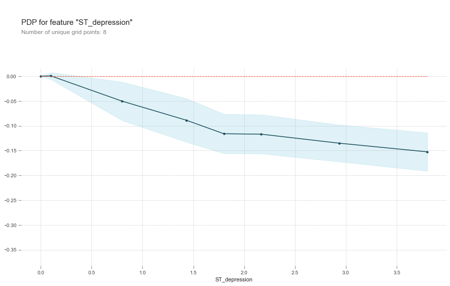

```python
feat_name = 'ST_depression'
pdp_dist = pdp.pdp_isolate(model=model, dataset=X_test, model_features=base_features, feature=feat_name)

pdp.pdp_plot(pdp_dist, feat_name)
plt.show()
```

Those values also shows a reduction in probability the higher it goes.

What is the ST segment in an electrocardiogram (ECG)? (find more [here](https://www.sharecare.com/health/circulatory-system-health/what-st-segment-electrocardiogram-ecg)) The ST segment represents the heart's electrical activity immediately after the right and left ventricles have contracted, pumping blood to the lungs and the rest of the body. Following this big effort, ventricular muscle cells relax and get ready for the next contraction.

**The shape and direction of the ST segment are far more important than its length. Upward or downward shifts can represent decreased blood flow to the heart from a variety of causes, including heart attack.**

So, this variable, which is described as 'ST depression induced by exercise relative to rest', seems to suggest the higher the value the higher the probability of heart disease, but the plot above shows the opposite.

Maybe it's not hust one factor, depression amount may have an interaction with the slope type.

[output not shown]

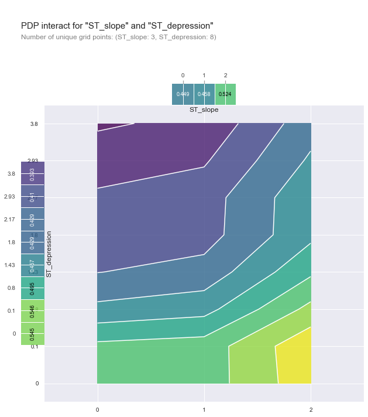

```python
# https://pdpbox.readthedocs.io/en/latest/pdp_interact_plot.html
inter  =  pdp.pdp_interact(model=model, dataset=X_test, model_features=base_features, features=['ST_slope', 'ST_depression'])

pdp.pdp_interact_plot(pdp_interact_out=inter, feature_names=['ST_slope', 'ST_depression'], plot_type='contour', x_quantile=True, plot_pdp=True)
plt.show()
```

Looks like low depression isn't that good for this case.

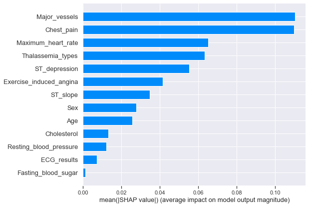

```python
explainer = shap.TreeExplainer(model)
shap_values = explainer.shap_values(X_test)

shap.summary_plot(shap_values[1], X_test, plot_type="bar")
```

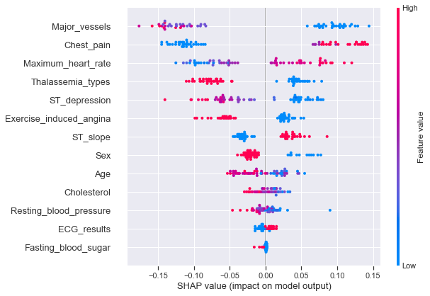

```python
# summary plot for shap
shap.summary_plot(shap_values[1], X_test)
```

The division of Major vessels is really clear and it descibes that low values (blue values on right) aren't that satisfying.

Let's pick out individual patients and see how the different variables are affecting their outcome

```python
def heart_disease_risk_factors(model, patient):

    explainer = shap.TreeExplainer(model)
    shap_values = explainer.shap_values(patient)
    shap.initjs()
    return shap.force_plot(explainer.expected_value[1], shap_values[1], patient)
```

```python
data_for_prediction = X_test.iloc[1,:].astype(float)
heart_disease_risk_factors(model, data_for_prediction)
```

Let's check another one:

```python
data_for_prediction = X_test.iloc[3,:].astype(float)
heart_disease_risk_factors(model, data_for_prediction)
```

We can alos plot something called 'SHAP dependency contribution plots' (learn more [here](https://www.kaggle.com/dansbecker/advanced-uses-of-shap-values))

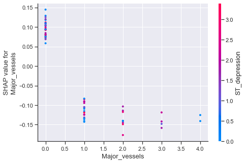

```python
ax2 = fig.add_subplot(224)
shap.dependence_plot('Major_vessels', shap_values[1], X_test, interaction_index="ST_depression")
```

You can see the stark effect on the number of major vessels, but there doesn't seem to be a lot to take from the colour, ST_depression.

The final plot shows the predictions and influencing factors for many (in this case 50) patients, all together. Hover over to see why each person ended up either red (prediction of disease) or blue (prediction of no disease), very interactive.

```python
shap_values = explainer.shap_values(X_train.iloc[:50])
shap.force_plot(explainer.expected_value[1], shap_values[1], X_test.iloc[:50])
```

### 8. Conclusion

Age is not such a huge critera for suffering from heart disease and parameters had very little relation amongst themselves.

The research taken showed various results where the patterns showed that the heart disease conditions could have been diagonsed a bit earlier.

### 9. References

[1] Heart Disease Data Set, https://archive.ics.uci.edu/ml/datasets/Heart+Disease

[2] Understand Your Risks to Prevent a Heart Attack, https://www.heart.org/en/health-topics/heart-attack/understand-your-risks-to-prevent-a-heart-attack

[3] Receiver operating characteristic, https://en.wikipedia.org/wiki/Receiver_operating_characteristic

[4] Permutation Importance, https://www.kaggle.com/dansbecker/permutation-importance

[5] Partial Dependence Plots, https://www.kaggle.com/dansbecker/partial-plots

[6] Advanced Uses of SHAP Values, https://www.kaggle.com/dansbecker/advanced-uses-of-shap-values